# Gradient Descent Exercise

## GRADIENT DESCENT

Gradient descent is a fundamental optimization algorithm used in machine learning to minimize the cost function or loss function associated with a model. It's widely used in various machine learning algorithms, including linear regression, logistic regression, neural networks, and more.

Objective: In machine learning, we aim to minimize a cost function J(θ), where θ represents the parameters of the model. Minimizing the cost function helps in finding the optimal parameters for the model that best fit the training data.

Gradient: The gradient of the cost functioncrepresents the direction of the steepest increase in the cost function.

Convergence: Gradient descent continues to update the parameters until convergence, i.e., until the change in the cost function or the parameters falls below a predefined threshold or after a certain number of iterations.

#### There are different variants of gradient descent, including:

1. Batch Gradient Descent: Computes the gradient using the entire training dataset in each iteration. It's computationally expensive for large datasets but guarantees convergence to the global minimum (for convex cost functions).
2. Stochastic Gradient Descent (SGD): Computes the gradient using only one training example at a time. It's faster and more suitable for large datasets but may suffer from noisy updates.
3. Mini-Batch Gradient Descent: Computes the gradient using a subset of the training dataset (mini-batch) in each iteration. It combines the advantages of both batch and stochastic gradient descent.

### 1. Import libraries

```python
# Importing necessary libraries
import numpy as np
import matplotlib.pyplot as plt
import pandas as pd
```

```python
# Define the dataset
#x = np.array([1,2,3,4,5])
#y = np.array([5,9,8,15,13])
```

### 2. Read the csv file from the laptop and assign x & y

```python
# Path to the CSV file
csv_file_path = "/Users/atikantjain/Documents/Sem2 (Feb'24-May'24)/Machine Learning/ML Practice/SOCR-HeightWeight.csv"

# Read data from the CSV file using pandas
df = pd.read_csv(csv_file_path)

# Extract x and y values from the DataFrame
x = df['Height(Inches)'].values
y = df['Weight(Pounds)'].values
```

### 3. Define Gradient Descent function

```python
def gradient_descent(x, y):
    m_curr = b_curr = 0   #Initially we have set both Slope and intercept to be 0
    n = len(x)
    epoch = 20 # Number of interations
    lr = 0.001
    # If you increase the lr and the cost value increases that means it has gone the other side and we need to reduce the lr
    gradients = []

    for i in range(epoch):
        y_predicted = b_curr + m_curr * x
        # We have used Mean Square Error - MSE as our loss function
        cost = (1/n) * sum([val**2 for val in (y-y_predicted)])
        md = -(2/n) * sum(x*(y-y_predicted)) # Derivative of Slope
        bd = -(2/n) * sum(y-y_predicted) # Derivative of Intercept
        m_curr = m_curr - lr * md
        b_curr = b_curr - lr * bd
        gradients.append((m_curr, b_curr))
        print("m {}, b {}, cost {}, iteration {}".format(m_curr, b_curr, cost, i))

    return gradients
```

### 4. Plot the graph with original points and gradient descent

```
m 17.303352203868535, b 0.2541588423215983, cost 16285.150375491492, iteration 0
m -125.5419956409435, b -1.845208217047601, cost 1102668.3218435275, iteration 1
m 1053.6974934828143, b 15.48462338327536, cost 75140696.29727904, iteration 2
m -8681.346527724321, b -127.58053376325009, cost 5120901465.034631, iteration 3
m 71684.9261086417, b 1053.4723474120838, cost 348994211323.7185, iteration 4
m -591767.4180010142, b -8696.54308660659, cost 23784281505524.492, iteration 5
m 4885269.135744586, b 71793.32270846533, cost 1620921002548016.0, iteration 6
m -40329627.87575708, b -592679.328373353, cost 1.1046728049794077e+17, iteration 7
m 332935529.6049769, b 4892780.223388298, cost 7.528448358327634e+18, iteration 8
m -2748501938.972418, b -40391651.65258359, cost 5.130707882780056e+20, iteration 9
m 22689867226.900887, b 333447541.0200309, cost 3.4966253503355776e+22, iteration 10
m -187312974764.24377, b -2752728793.517816, cost 2.38298283978407e+24, iteration 11
m 1546335647000.4512, b 22724761406.92275, cost 1.6240250658139007e+26, iteration 12
m -12765554207677.59, b -187601038726.20352, cost 1.1067882530915954e+28, iteration 13
m 105384218843759.67, b 1548713718088.9585, cost 7.54286533482545e+29, iteration 14
m -869984444124486.5, b -12785186035654.54, cost 5.140533186938596e+31, iteration 15
m 7182032958281262.0, b 105546286610026.66, cost 3.503321386902181e+33, iteration 16
m -5.929025255819102e+16, b -871322371539956.8, cost 2.3875462512548083e+35, iteration 17
m 4.89462255162827e+17, b 7193078027947130.0, cost 1.627135073360052e+37, iteration 18
m -4.0406860974989036e+18, b -5.938143356137286e+16, cost 1.1089077522862517e+39, iteration 19
```

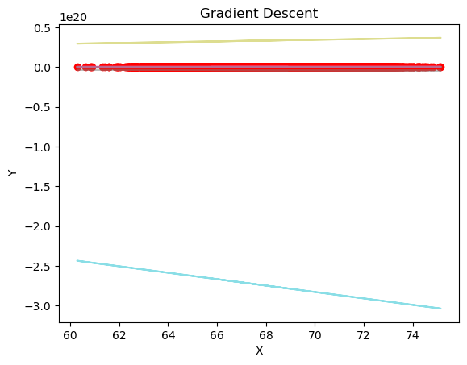

```python
gradients = gradient_descent(x, y)

# Plotting the original points
plt.scatter(x, y, color='red', label='Original Points')

# Plotting the gradients for each iteration
for m, b in gradients:
    y_predicted = m * x + b
    plt.plot(x, y_predicted, label='Gradient Line', alpha=0.5)  # Reduced alpha for better visualization

plt.xlabel('X')
plt.ylabel('Y')
plt.title('Gradient Descent')
#plt.legend()
plt.show()
```

```python
#   In the Example with dataset:
#    x = np.array([1,2,3,4,5])
#    y = np.array([5,9,8,15,13])
#    epoch = 1000 & lr = 0.08
#   Final Equation is :::::
#    y = 2.2000000000008875 * x + 3.3999999999968
```